# CSDA1040 Assignment 3 Time Series Analysis

```r
# forecasting 12 months ahead
var.f12 <- predict(var.4_train, n.ahead = 12, ci = 0.95)
names(var.f12)
```

```
## [1] "fcst"     "endog"    "model"    "exo.fcst"
```

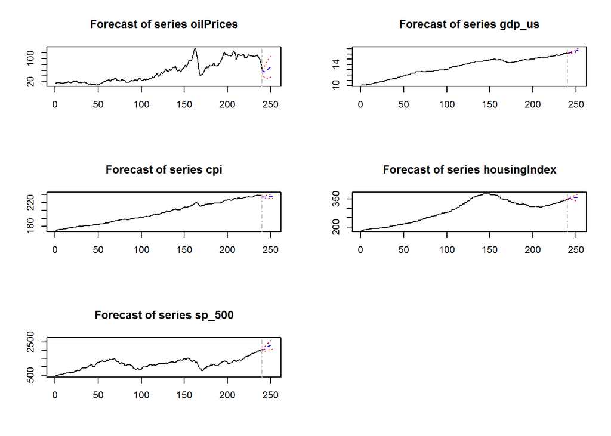

```r
plot(var.f12)
```

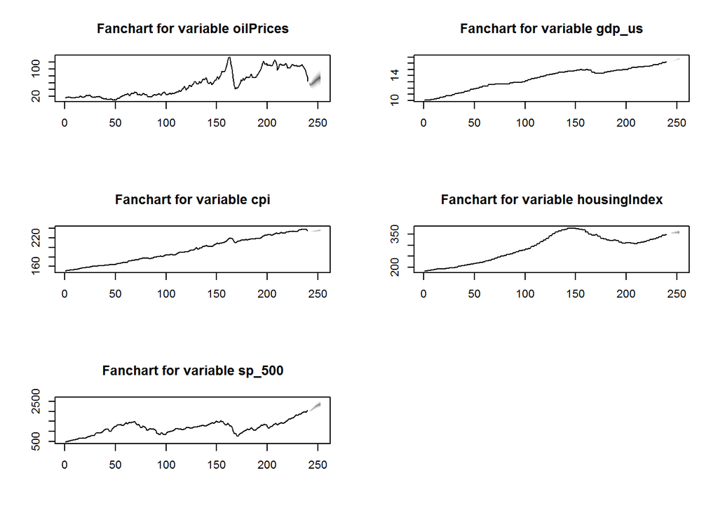

```r
fanchart(var.f12)
```

# PERFORM CLUSTERING ON FOUR INDICES (SP_500, NYSE, NASDAQ and HANG_SENG)

# Time Series Clustering

##Time series clustering is to partition time series data into groups based on similarity or distance, so that time series in the same cluster are similar. For time series clustering with R, the first step is to work out an appropriate distance/similarity metric, and then, at the second step, use existing clustering techniques, such as k-means, hierarchical clustering, density-based clustering or subspace clustering, to find clustering structures.

### Measures of distance/dissimilarity

### Euclidean distance

### Manhattan distance

### Maximum norm

### Hamming distance

### The angle between two vectors (inner product)

### Dynamic Time Warping (DTW) distance

```r
# Get all four indices in a data file
head(dta_2) # nasdaq, nyse and sp_500
```

```
##     nasdaq     nyse   sp_500
## 1 755.3225 2679.487 464.5475
## 2 775.7775 2753.165 479.0725
## 3 807.9525 2823.107 493.9875
## 4 828.8375 2901.430 507.7250
## 5 858.6625 2979.570 523.6500
## 6 901.0325 3059.908 538.8050
```

```r
#add hang seng
data_stockindices <- dta_2 %>%
  cbind(data_hseng$Hang_Seng)

colnames(data_stockindices)[4] <- c("hseng")
str(data_stockindices)
```

```
## 'data.frame':    252 obs. of  4 variables:
##  $ nasdaq: num  755 776 808 829 859 ...
##  $ nyse  : num  2679 2753 2823 2901 2980 ...
##  $ sp_500: num  465 479 494 508 524 ...
##  $ hseng : num  8328 8588 8361 9407 9206 ...
```

```r
head(data_stockindices)
```

```
##     nasdaq     nyse   sp_500  hseng
## 1 755.3225 2679.487 464.5475 8327.5
## 2 775.7775 2753.165 479.0725 8587.7
## 3 807.9525 2823.107 493.9875 8361.0
## 4 828.8375 2901.430 507.7250 9407.4
## 5 858.6625 2979.570 523.6500 9206.5
## 6 901.0325 3059.908 538.8050 9453.4
```

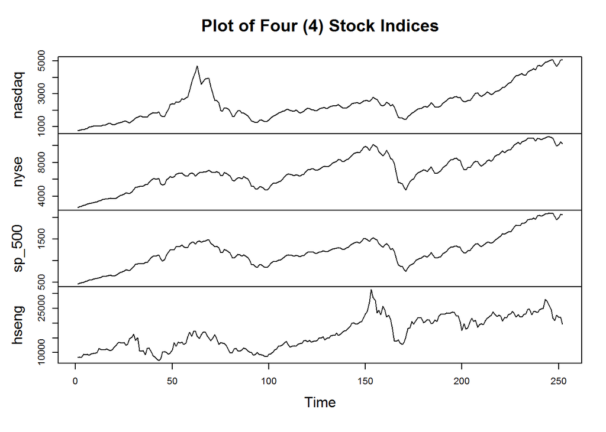

```r
plot.ts(data_stockindices, main = "Plot of Four (4) Stock Indices")
```

## Hierarchical Clustering with Dynamic Time Warping (DTW) Distance

### Compute DTW Distances

### DTW finds optimal alignment between two time series, and DTW distance is used as a distance metric.

```r
library(dtw)
distMatrix_dtw <- dist(t(data_stockindices), method="DTW")
distMatrix_dtw
```

```
##           nasdaq      nyse    sp_500
## nyse    708754.2
## sp_500  179736.4 1623167.6
## hseng  4193271.8 1955052.9 5231035.9
```

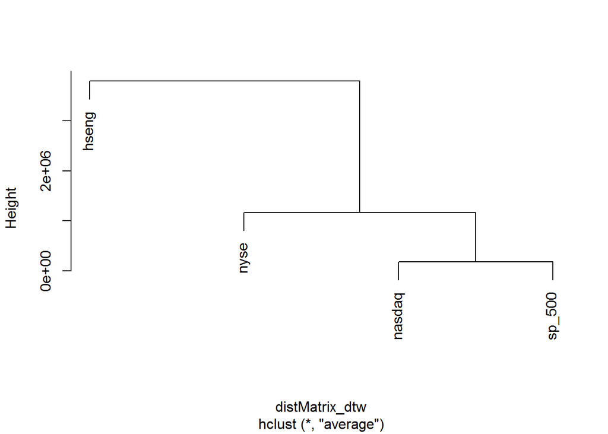

```r
observedLabels <- c("nasdaq", "nyse", "sp500", "hseng")

hc <- hclust(distMatrix_dtw, method="average")
#plot(hc, labels = observedLabels, main = "")
plot(hc,main="")
```

```r
# since we have only 4 maximum clusters, get 3 clusters
memb <- cutree(hc, k = 3)
#str(memb)
table(observedLabels, memb)
```

```
##               memb
## observedLabels 1 2 3
##         hseng  0 0 1
##         nasdaq 1 0 0
##         nyse   0 1 0
##         sp500  1 0 0
```

## Hierarchical clustering with Euclidean distance

```r
distMatrix_euc <- dist(t(data_stockindices)) # method="Euclidean" ommitted because it is the default, but you can add it
distMatrix_euc
```

```
##           nasdaq      nyse    sp_500
## nyse    76377.14
## sp_500  21862.00  96293.30
## hseng  236209.56 162434.51 256172.28
```

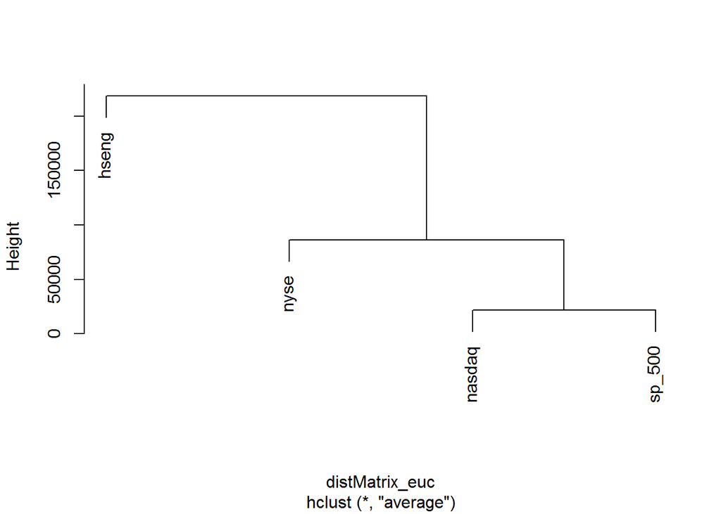

```r
hc <- hclust(distMatrix_euc, method = "ave")
#plot(hc, labels = observedLabels, main = "")
plot(hc, main = "")
```

```r
# Since we have only 4 maximum clusters, get all 3 clusters
memb_euc <- cutree(hc, k = 3)
table(observedLabels, memb_euc)
```

```
##               memb_euc
## observedLabels 1 2 3
##         hseng  0 0 1
##         nasdaq 1 0 0
##         nyse   0 1 0
##         sp500  1 0 0
```

```r
# From the dendogram plots and tables, both DTW and EUCLIDIAN give the same clustering results
```

## K-Means Clustering

```r
ds <- t(data_stockindices)
set.seed(123)
km_clus_3 <- kmeans(ds, centers=3)
sort(km_clus_3$cluster)
```

```
##  hseng nasdaq sp_500   nyse
##      1      2      2      3
```

```r
# Results from K-Means Clustering also align with those in the two types of Hierarchical clustering
```

# Conclusion

## Our project focuses on how to reduce investment risk by predicting the future value of varied stock indices using time series analysis. We performed both a univariate and multivariate time series analysis, followed by a clustering analysis to segment the various indices into groupings to help guide investors when diversifying their investment portfolios. Our results indicated that the NaÃ¯ve models performed better than ARIMA and Exponential Smoothing when forecasting the S&P500’s performance. We also determined that in a three-cluster solution, both the S&P500 and NASDAQ were in one cluster, and NYSE and then Heng Seng were in separate clusters themselves.

## We have demonstrated that our model can help predict the performance of various stock exchanges. Evolution of our project would involve ingesting additional global indices. We can then segregate by industry-specific segments and even the underlying stocks themselves. Evolution of our Shiny app would provide an option for a fund manager to help diversify a given portfolio by selecting various stocks across a spectrum of available stocks.

# Sources Cited

### 1) Hyndman, Rob J., and George Athanasopoulos. “Forecasting: Principles and Practice” Otexts. N.p., May 2012. Web.

### 2) Schmidt, Drew. Autoplot: Graphical Methods with ggplot2 Wrathematics, my stack runneth over. June, 2012. Web.